# Predicting Hit Songs of 2020

Rifaa Qadri & Paulina Hong

5/13/2020

## Introduction

In this project, we will walk you through the entire data science pipeline process. This includes tasks such as importing required libraries, collecting the data, cleaning it up, making graphs to represent this data. We will discover the needed predictors to find the top songs for 2020.

As you probably know, everyone has been stuck at home during quarantine. Whether they are studying, playing in their yard, or doing work, they are most likely listening to some music throughout their day. Upon interviewing many of our peers, we were informed that their music taste has expanded and they have been listening to a variety of music genres.’ They mentioned the “30 days song challenge” on social media where people post one of their songs depending on the theme of the day (such as “a classic favorite” “what song motivates you” or “a song that reminds you of someone”), which have influenced people to discover their friends’ music taste and expand their own playlists.

Therefore, we have decided to work on a dataset that has the top 2000 songs on Spotify but just focusing on the years 2010-2019. We want to study which attributes would be good predictors for the top songs for 2020.

Some attributes we can think can contribute to this is the genre, the danceability, the loudness and speechness.

The data used in this project can be accessed through [here](https://www.kaggle.com/iamsumat/spotify-top-2000s-mega-dataset)

## Imports

We will use the following libraries throughout our project:

```r
library(ggplot2)
library(dplyr)
library(tidyverse)
library(scales)
```

## Loading Data

```r
data <- read.csv(file="~/Downloads/Spotify-2000.csv",header = TRUE, sep = ",")
as_tibble(data)
```

```
## # A tibble: 1,994 x 15
##    Index Title Artist Top.Genre  Year Beats.Per.Minut… Energy Danceability
##    <int> <fct> <fct>  <fct>     <int>            <int>  <int>        <int>
##  1     1 Sunr… Norah… adult st…  2004              157     30           53
##  2     2 Blac… Deep … album ro…  2000              135     79           50
##  3     3 Clin… Goril… alternat…  2001              168     69           66
##  4     4 The … Foo F… alternat…  2007              173     96           43
##  5     5 Wait… Bruce… classic …  2002              106     82           58
##  6     6 The … City … alternat…  2004               99     46           54
##  7     7 She … Maroo… pop        2002              102     71           71
##  8     8 Knig… Muse   modern r…  2006              137     96           37
##  9     9 Mr. … The K… modern r…  2004              148     92           36
## 10    10 With… Eminem detroit …  2002              112     67           91
## # … with 1,984 more rows, and 7 more variables: Loudness..dB. <int>,
## #   Liveness <int>, Valence <int>, Length..Duration. <fct>, Acousticness <int>,
## #   Speechiness <int>, Popularity <int>
```

Looking at the data set, we see that everything looks okay with no NA or any non-understandable variables. We don’t have any missing data in our dataset, but we still have to tidy it so the attribute names are easier to read and only use the information that would be helpful in our prediction.

Some insight about this dataset:

- **Beats per minute:** The tempo of the song
- **Energy:** The higher the value, more energetic the song
- **Danceability:** The higher the value, the easier it is to dance to the song
- **Loudness:** The higher the value, the louder the song
- **Liveness:** The higher the value, the more likely the song is a live recording
- **Valence:** The higher the value, the more positive the song
- **Acousticness:** The higher the value, the more acoustic a song is
- **Speechiness:** The higher the value, the spoken words in the song
- **Popularity:** The higher the value, the more popular a song is

## Tidying Data

To make it easier to read, we will be renaming the columns and selecting the attributes that are most important to our analysis:

```r
tidy_data <- data %>%
  magrittr::set_colnames(c("id", "track", "artist", "genre","year", "bpm", "energy", "dance",
                           "loudness","liveness", "valance", "duration", "acousticness",
                           "speechness", "popularity"))%>%
  filter(year >= 2010) %>%
  select(artist, track, genre, year, dance, loudness, speechness, popularity)
as_tibble(tidy_data)
```

```
## # A tibble: 399 x 8
##    artist      track          genre    year dance loudness speechness popularity
##    <fct>       <fct>          <fct>   <int> <int>    <int>      <int>      <int>
##  1 Claudia De… Mag Ik Dan Bi… dutch …  2010    54      -10          3         53
##  2 De Jeugd V… Sterrenstof    dutch …  2010    71       -4         11         48
##  3 Joy Divisi… Love Will Tea… altern…  2010    53       -9          4         64
##  4 De Dijk     Mag Het Licht… dutch …  2010    74      -10          3         43
##  5 Anita Meyer Why Tell Me W… dutch …  2010    65       -6          6         54
##  6 Charly Low… Wonderful Days happy …  2010    55      -11          7         37
##  7 Guus Meeuw… Dat Komt Door… dutch …  2010    59      -10          4         57
##  8 Racoon      Don't Give up… dutch …  2010    28      -13          3         27
##  9 Triggerfin… I Follow Rive… belgia…  2010    67       -9          6         42
## 10 Racoon      Liverpool Rain dutch …  2010    45       -7          3         26
## # … with 389 more rows
```

After tidying the data, we have decided that the attributes we want to focus on our predictions would be track, genre, year, danceability (the higher value, the easier it is to dance), loudness (the higher the value, the louder it is), speechiness (higher value, the more words a song has) and popularity (higher the value, more popular the song) from the years 2010-2019, so we can have a more accurate estimate.

### Tidying Genres

Because our dataset had a total of 96 genres, and some of them have the same genre type like “pop” or “rock”, we decided to group all the ones that have similar words to them into one genre so it would be much easier to read the data as well. We ended grouping genres such as “pop”, “rock”, “hip hop”, “soul”, “indie”, “dance”, etc.

```r
tidy_data[,3] <- sapply(tidy_data[,3],as.character)

# Replacing all the pop genres into one
tidy_data$genre = str_replace_all(tidy_data$genre, "dutch pop", "pop")
tidy_data$genre = str_replace_all(tidy_data$genre, "belgian pop", "pop")
tidy_data$genre = str_replace_all(tidy_data$genre, "classic uk pop", "pop")
tidy_data$genre = str_replace_all(tidy_data$genre, "barbadian pop", "pop")
tidy_data$genre = str_replace_all(tidy_data$genre, "australian pop", "pop")
tidy_data$genre = str_replace_all(tidy_data$genre, "indie pop", "pop")
tidy_data$genre = str_replace_all(tidy_data$genre, "dance pop", "pop")
tidy_data$genre = str_replace_all(tidy_data$genre, "art pop", "pop")
tidy_data$genre = str_replace_all(tidy_data$genre, "folk-pop", "pop")
tidy_data$genre = str_replace_all(tidy_data$genre, "electropop", "pop")
tidy_data$genre = str_replace_all(tidy_data$genre, "chamber pop", "pop")
tidy_data$genre = str_replace_all(tidy_data$genre, "brill building pop", "pop")
tidy_data$genre = str_replace_all(tidy_data$genre, "britpop", "pop")
tidy_data$genre = str_replace_all(tidy_data$genre, "acoustic pop", "pop")
tidy_data$genre = str_replace_all(tidy_data$genre, "nederpop", "pop")
tidy_data$genre = str_replace_all(tidy_data$genre, "irish pop", "pop")
tidy_data$genre = str_replace_all(tidy_data$genre, "canadian pop", "pop")
tidy_data$genre = str_replace_all(tidy_data$genre, "danish pop", "pop")
tidy_data$genre = str_replace_all(tidy_data$genre, "italian pop", "pop")
tidy_data$genre = str_replace_all(tidy_data$genre, "german pop", "pop")
tidy_data$genre = str_replace_all(tidy_data$genre, "baroque pop", "pop")
tidy_data$genre = str_replace_all(tidy_data$genre, "austropop", "pop")
tidy_data$genre = str_replace_all(tidy_data$genre, "la pop", "pop")

# Replacing all the rock genres into one
tidy_data$genre = str_replace_all(tidy_data$genre, "alternative rock", "rock")
tidy_data$genre = str_replace_all(tidy_data$genre, "belgian rock", "rock")
tidy_data$genre = str_replace_all(tidy_data$genre, "album rock", "rock")
tidy_data$genre = str_replace_all(tidy_data$genre, "dance rock", "rock")
tidy_data$genre = str_replace_all(tidy_data$genre, "modern rock", "rock")
tidy_data$genre = str_replace_all(tidy_data$genre, "australian rock", "rock")
tidy_data$genre = str_replace_all(tidy_data$genre, "celtic rock", "rock")
tidy_data$genre = str_replace_all(tidy_data$genre, "dutch rock", "rock")
tidy_data$genre = str_replace_all(tidy_data$genre, "garage rock", "rock")
tidy_data$genre = str_replace_all(tidy_data$genre, "blues rock", "rock")
tidy_data$genre = str_replace_all(tidy_data$genre, "art rock", "rock")
tidy_data$genre = str_replace_all(tidy_data$genre, "irish rock", "rock")
tidy_data$genre = str_replace_all(tidy_data$genre, "classic rock", "rock")
tidy_data$genre = str_replace_all(tidy_data$genre, "glam rock", "rock")

# Replacing all the country genres into one
tidy_data$genre = str_replace_all(tidy_data$genre, "contemporary country", "country")
tidy_data$genre = str_replace_all(tidy_data$genre, "arkansas country", "country")

# Replacing all the soul genres into one
tidy_data$genre = str_replace_all(tidy_data$genre, "british soul", "soul")
tidy_data$genre = str_replace_all(tidy_data$genre, "neo soul", "soul")

# Replacing all the hip hop genres into one
tidy_data$genre = str_replace_all(tidy_data$genre, "dutch hip hop", "hip hop")
tidy_data$genre = str_replace_all(tidy_data$genre, "east coast hip hop", "hip hop")
tidy_data$genre = str_replace_all(tidy_data$genre, "detroit hip hop", "hip hop")

# Replacing all the indie genres into one
tidy_data$genre = str_replace_all(tidy_data$genre, "dutch indie", "indie")
tidy_data$genre = str_replace_all(tidy_data$genre, "icelandic indie", "indie")
tidy_data$genre = str_replace_all(tidy_data$genre, "alaska indie", "indie")
tidy_data$genre = str_replace_all(tidy_data$genre, "alaska indie", "indie")

# Replacing all the dance genres into one
tidy_data$genre = str_replace_all(tidy_data$genre, "alternative dance", "dance")
tidy_data$genre = str_replace_all(tidy_data$genre, "eurodance", "dance")
tidy_data$genre = str_replace_all(tidy_data$genre, "australian dance", "dance")

# Replacing all the metal genres into one
tidy_data$genre = str_replace_all(tidy_data$genre, "finnish metal", "metal")
tidy_data$genre = str_replace_all(tidy_data$genre, "alternative metal", "metal")
tidy_data$genre = str_replace_all(tidy_data$genre, "dutch metal", "metal")

# Replacing all the fold genres into one
tidy_data$genre = str_replace_all(tidy_data$genre, "australian indie folk", "folk")
tidy_data$genre = str_replace_all(tidy_data$genre, "canadian folk", "folk")
tidy_data$genre = str_replace_all(tidy_data$genre, "indie anthem-folk", "folk")
tidy_data$genre = str_replace_all(tidy_data$genre, "australian indie folk", "folk")

# Replacing all the electro genres into one
tidy_data$genre = str_replace_all(tidy_data$genre, "electronica", "electro")
tidy_data$genre = str_replace_all(tidy_data$genre, "edm", "electro")
tidy_data$genre = str_replace_all(tidy_data$genre, "electro house", "electro")

# Replacing all the dutch genres into one
tidy_data$genre = str_replace_all(tidy_data$genre, "dutch cabaret", "dutch music")
tidy_data$genre = str_replace_all(tidy_data$genre, "dutch americana", "dutch music")
tidy_data$genre = str_replace_all(tidy_data$genre, "dutch prog", "dutch music")
tidy_data$genre = str_replace_all(tidy_data$genre, "dutch americana", "dutch music")

# Replacing all the british genres into one
tidy_data$genre = str_replace_all(tidy_data$genre, "british singer-songwriter", "british music")
tidy_data$genre = str_replace_all(tidy_data$genre, "british invasion", "british music")

# Replacing all the australian genres into one
tidy_data$genre = str_replace_all(tidy_data$genre, "australian psych", "australian music")
tidy_data$genre = str_replace_all(tidy_data$genre, "australian americana", "australian music")

as_tibble(tidy_data)
```

```
## # A tibble: 399 x 8
##    artist      track          genre    year dance loudness speechness popularity
##    <fct>       <fct>          <chr>   <int> <int>    <int>      <int>      <int>
##  1 Claudia De… Mag Ik Dan Bi… dutch …  2010    54      -10          3         53
##  2 De Jeugd V… Sterrenstof    hip hop  2010    71       -4         11         48
##  3 Joy Divisi… Love Will Tea… rock     2010    53       -9          4         64
##  4 De Dijk     Mag Het Licht… indie    2010    74      -10          3         43
##  5 Anita Meyer Why Tell Me W… pop      2010    65       -6          6         54
##  6 Charly Low… Wonderful Days happy …  2010    55      -11          7         37
##  7 Guus Meeuw… Dat Komt Door… pop      2010    59      -10          4         57
##  8 Racoon      Don't Give up… indie    2010    28      -13          3         27
##  9 Triggerfin… I Follow Rive… rock     2010    67       -9          6         42
## 10 Racoon      Liverpool Rain indie    2010    45       -7          3         26
## # … with 389 more rows
```

We get a cleaner dataset where we can visualize the general genre that each sub-genre had for every song which will help us visualize the data in more straightforward way.

### Deleting some Genres

```r
new_data <- tidy_data[-c(6, 17, 59, 168, 180, 222, 234, 236, 263, 291, 295, 350),]
as_tibble(new_data)
```

```
## # A tibble: 387 x 8
##    artist       track          genre   year dance loudness speechness popularity
##    <fct>        <fct>          <chr>  <int> <int>    <int>      <int>      <int>
##  1 Claudia De … Mag Ik Dan Bi… dutch…  2010    54      -10          3         53
##  2 De Jeugd Va… Sterrenstof    hip h…  2010    71       -4         11         48
##  3 Joy Division Love Will Tea… rock    2010    53       -9          4         64
##  4 De Dijk      Mag Het Licht… indie   2010    74      -10          3         43
##  5 Anita Meyer  Why Tell Me W… pop     2010    65       -6          6         54
##  6 Guus Meeuwis Dat Komt Door… pop     2010    59      -10          4         57
##  7 Racoon       Don't Give up… indie   2010    28      -13          3         27
##  8 Triggerfing… I Follow Rive… rock    2010    67       -9          6         42
##  9 Racoon       Liverpool Rain indie   2010    45       -7          3         26
## 10 Racoon       No Mercy       indie   2010    77       -6          3         36
## # … with 377 more rows
```

```r
new_data %>%
  group_by(genre) %>%
  summarise()
```

```
## # A tibble: 30 x 1
##    genre
##    <chr>
##  1 adult standards
##  2 alternative pop rock
##  3 australian music
##  4 big room
##  5 boy band
##  6 british music
##  7 compositional ambient
##  8 contemporary vocal jazz
##  9 country
## 10 dance
## # … with 20 more rows
```

And finally, we get the dataset with that total of 30 genres that we want to work with to make our predictions.

## Visualizing the Data

We will start by plotting how well every genre has been listened to over the years. The x-axis doesn’t display the years because while doing geom_bar, it displays them in scientific notation, so we decided to get rid of it but knowing that the years are increasing.

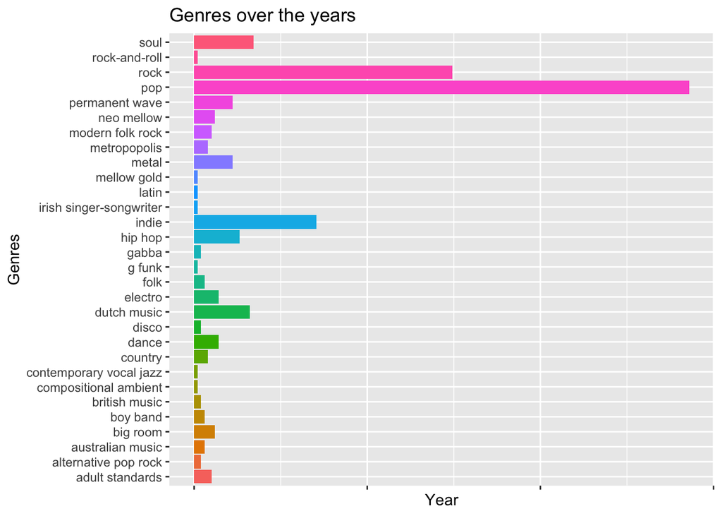

```r
new_data %>%
  group_by(genre) %>%
  ggplot(aes(x=year, y=genre, fill=genre)) +
  geom_bar(stat="identity") +
  theme(legend.position = "none") +
  theme(axis.text.x = element_blank()) +
  labs(title="Genres over the years", x="Year", y="Genres")
```

From the graph above we can clearly see that the most prominent genre that has been doing really well over the years is pop, followed by rock and indie. This means that over the years, songs within those genres have always been produced every year because it seems that it appeals and is well received by the public.

Next, we would be plotting the popularity among genres.

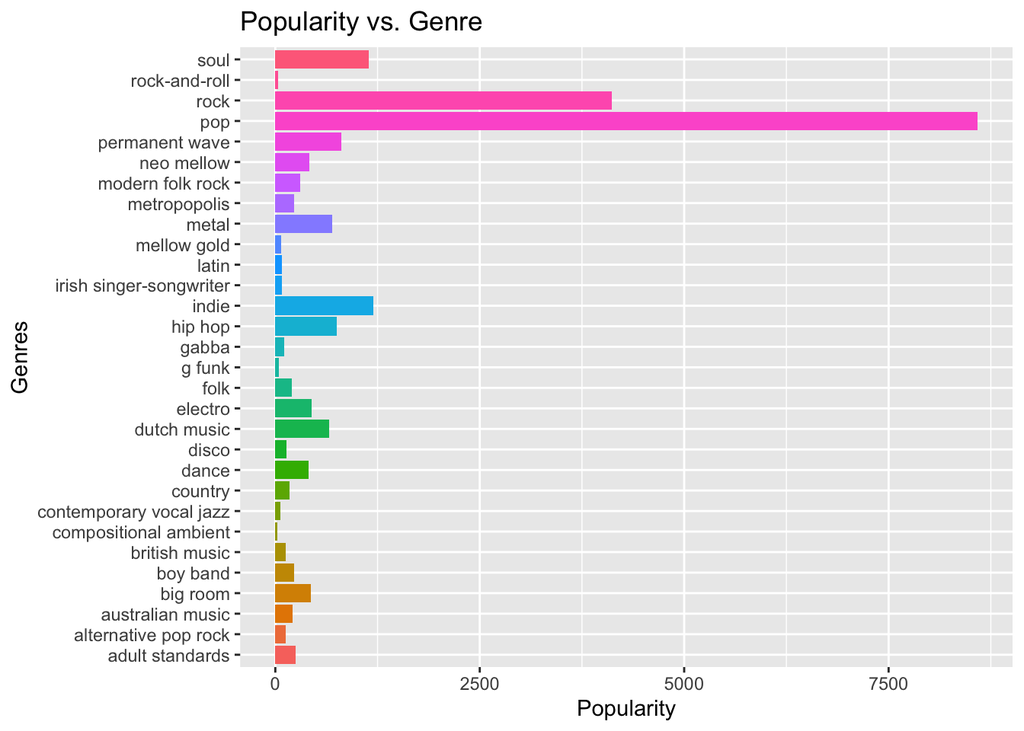

```r
new_data %>%
  group_by(genre) %>%
  ggplot(aes(x=popularity, y=genre, fill=genre)) +
  geom_bar(stat = "identity") +
  theme(legend.position = "none") +
  labs(title="Popularity vs. Genre", x="Popularity", y="Genres")
```

It is not surprising how pop is the most popular genre for people to listen to. It is the genre that will be played everywhere such as shopping malls, cafeterias, parties and it has a general tone to it that makes people like it and want to listen to it more. Rock is also one of the most popular genres, but you don’t see it playing anywhere because it is not as mainstream as pop music. It is the type of music people listen to provide an alternative root of escape from the world.

Soul and hip-hop are very important genres because the songs address important political and social issues (poverty, racism, violence) that are ignored by the masses, so this genre is mostly to express the social angst of people and for them to be able to know that not everything is being swept under the carpet.

And finally, there has also been a rise in indie music, because there has been a growth in independent artists throughout the years and people listen to it because there is a powerful vibe to it that feels like the artist is talking to you, something that pop can’t do.

Next, we will be plotting the relationship between danceability and every genre.

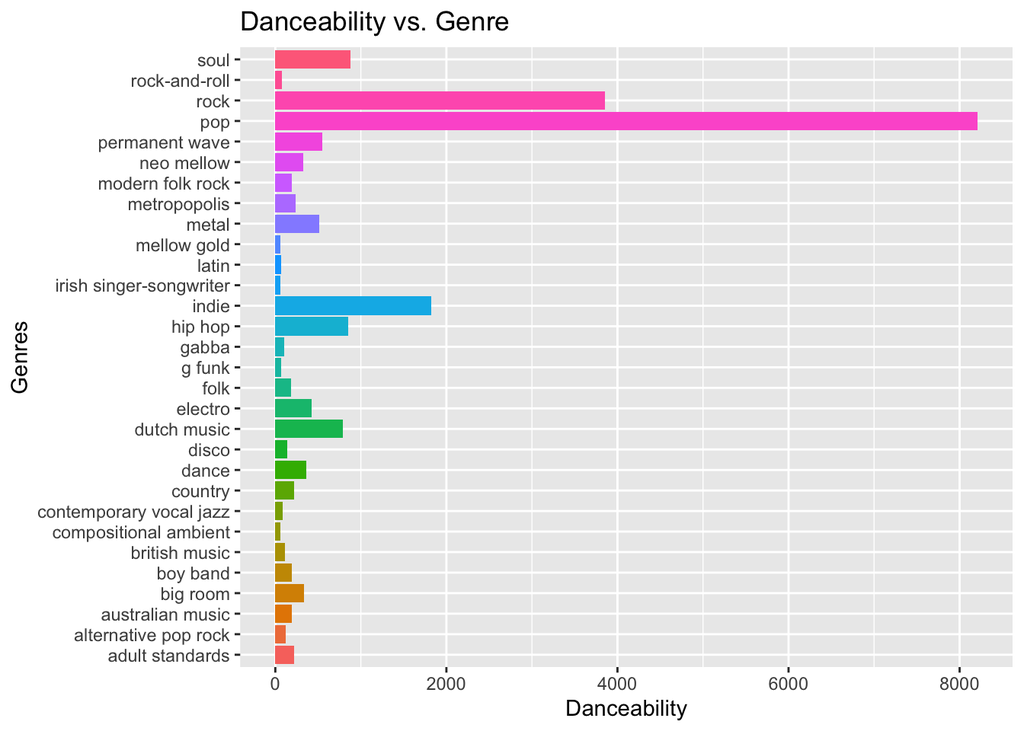

```r
new_data %>%
  arrange(desc(dance)) %>%
  ggplot(aes(x=dance, y=genre, fill=genre)) +
  geom_bar(stat = "identity") +
  theme(legend.position = "none") +
  labs(title="Danceability vs. Genre", x="Danceability", y="Genres")
```

We can clearly notice how pop is the most popular genre amongst the other ones, having a higher danceability rate means that people are more likely to dance to it and thus enjoy it and listen to it more. This is because pop music is most likely to be played more than any genre in public places.

## Data Modelling

Now that we have a clear idea about out dataset, we can start building a model that would be useful to predict the top songs for 2020.

### First Model: Linear Regression

The first model we are going to use is linear regression, so we can see if our predictor variables do a good job in predicting the outcome and which attributes are significant predictors for us to use in our analysis.

We will start by plotting the relationship between danceability and popularity and see how well the linear model captures that relationship.

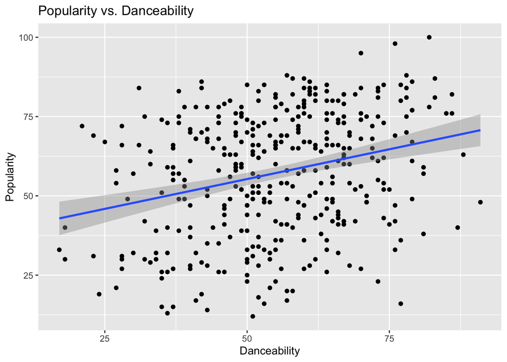

```r
new_data %>%
  group_by(year) %>%
  ggplot(aes(x=dance, y=popularity)) +
  geom_point() +
  geom_smooth(method=lm) +
  xlab("Danceability") +
  ylab("Popularity") +
  ggtitle("Popularity vs. Danceability")
```

```r
model_popularity <- lm(popularity~dance, data=new_data)

model1 <- broom::tidy(model_popularity)
model1
```

```
## # A tibble: 2 x 5
##   term        estimate std.error statistic  p.value
##   <chr>          <dbl>     <dbl>     <dbl>    <dbl>
## 1 (Intercept)   36.5      3.76        9.70 4.80e-20
## 2 dance          0.376    0.0661      5.68 2.62e- 8
```

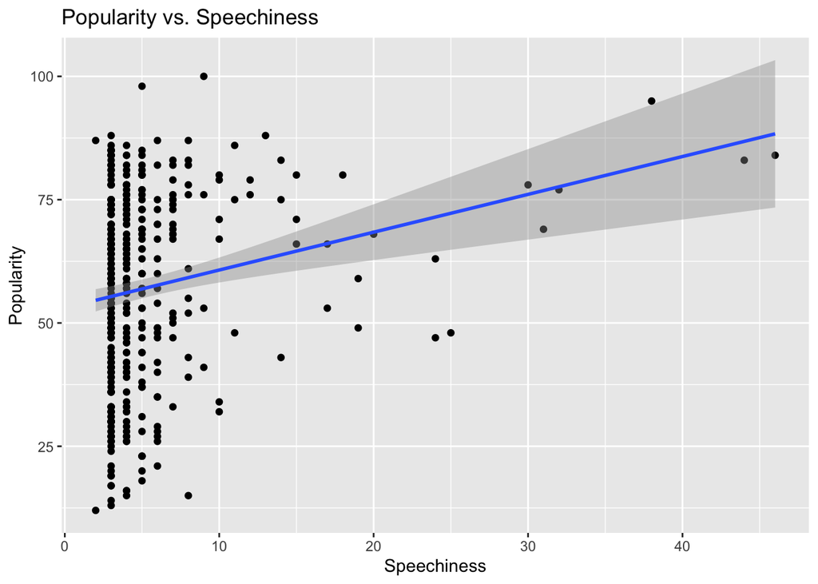

```r
new_data %>%
  group_by(year) %>%
  ggplot(aes(x=speechness, y=popularity)) +
  geom_point() +
  geom_smooth(method=lm) +
  xlab("Speechiness") +
  ylab("Popularity") +
  ggtitle("Popularity vs. Speechiness")
```

```r
model_speech <- lm(popularity~speechness, data=new_data)

model2 <- broom::tidy(model_speech)
model2
```

```
## # A tibble: 2 x 5
##   term        estimate std.error statistic   p.value
##   <chr>          <dbl>     <dbl>     <dbl>     <dbl>
## 1 (Intercept)   53.1       1.39      38.2  6.40e-133
## 2 speechness     0.767     0.186      4.13 4.44e-  5
```

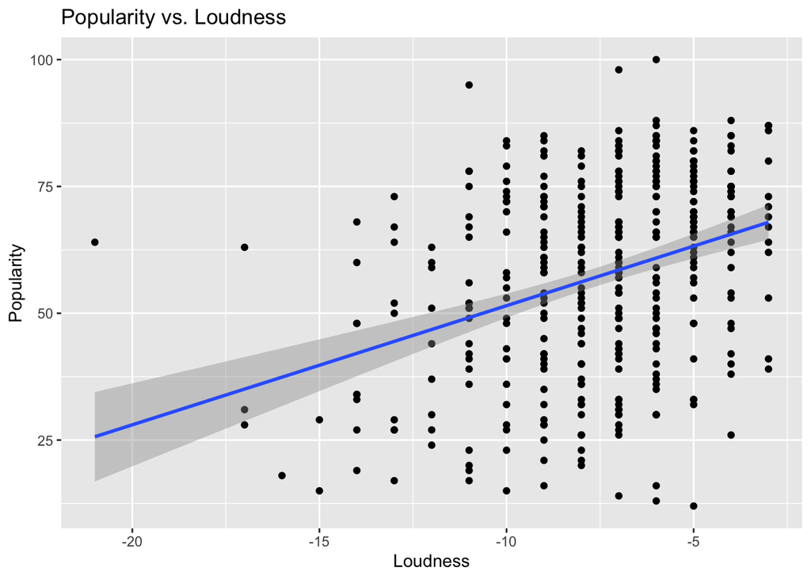

```r
new_data %>%
  group_by(year) %>%
  ggplot(aes(x=loudness, y=popularity)) +
  geom_point() +
  geom_smooth(method=lm) +
  xlab("Loudness") +
  ylab("Popularity") +
  ggtitle("Popularity vs. Loudness")
```

```r
model_loudness <- lm(popularity~loudness, data=new_data)

model3 <- broom::tidy(model_loudness)
model3
```

```
## # A tibble: 2 x 5
##   term        estimate std.error statistic  p.value
##   <chr>          <dbl>     <dbl>     <dbl>    <dbl>
## 1 (Intercept)    75.0      2.64      28.4  1.32e-96
## 2 loudness        2.35     0.326      7.20 3.26e-12
```

But now, what is the relationship of our regression model if we include the interaction from all the other attributes?

```r
model_interaction <- lm(popularity~dance*loudness*speechness, data=new_data)

model4 <- broom::tidy(model_interaction)
model4
```

```
## # A tibble: 8 x 5
##   term                      estimate std.error statistic p.value
##   <chr>                        <dbl>     <dbl>     <dbl>   <dbl>
## 1 (Intercept)               64.2      20.3         3.17  0.00168
## 2 dance                      0.167     0.346       0.482 0.630
## 3 loudness                   3.68      2.40        1.53  0.126
## 4 speechness                -1.33      3.49       -0.381 0.704
## 5 dance:loudness            -0.0206    0.0408     -0.507 0.613
## 6 dance:speechness           0.0230    0.0558      0.412 0.681
## 7 loudness:speechness       -0.301     0.431      -0.697 0.486
## 8 dance:loudness:speechness  0.00390   0.00679     0.574 0.566
```

### Second Model: Hypotheis Testing

When we initially looked over at the data, we noticed that the popularity and danceability levels seen in the pop genre were off the chart. We will use hypothesis testing to see if the difference between the popularity rates and danceability rates between genres is significantly high in predicting the top genre in 2020.

Our null hypothesis is that the rates of popularity and danceability is statistically significant between genres. Our alternative hypothesis is that the rates of popularity and danceability is higher in pop than any other genre. We will reject the null hypothesis if alpha is less than 0.05 $(\alpha < 0.05)$.

First, we will gather the data we need:

```r
our_predictions <- group_by(new_data, genre) %>%
  mutate(total_popularity = sum(popularity)) %>%
  mutate(total_danceability = n()) %>%
  select(total_popularity,total_danceability) %>%
  distinct()
our_predictions
```

```
## # A tibble: 30 x 3
## # Groups:   genre [30]
##    genre           total_popularity total_danceability
##    <chr>                      <int>              <int>
##  1 dutch music                  657                 16
##  2 hip hop                      750                 13
##  3 rock                        4113                 74
##  4 indie                       1200                 35
##  5 pop                         8590                142
##  6 permanent wave               807                 11
##  7 country                      176                  4
##  8 adult standards              245                  5
##  9 gabba                        107                  2
## 10 soul                        1145                 17
## # … with 20 more rows
```

Then, we will pick the two genres we want to focus on: pop and rock and collect the popularity and danceability statistics in regard to them.

```r
# popularity for pop
pop_popular <- our_predictions$total_popularity[our_predictions$genre=="pop"]
pop_popular <- as.data.frame(pop_popular)
names(pop_popular)[1] <- "adding"
pop_popular[,1] <- sapply(pop_popular[,1],as.integer)

sum_pop_population <- sum(pop_popular$adding,na.rm = TRUE)

# danceabiltiy for pop
pop_danceability <- our_predictions$total_danceability[our_predictions$genre=="pop"]
pop_danceability <- as.data.frame(pop_danceability)
names(pop_danceability)[1] <- "adding"
sum_pop_danceability <- sum(pop_danceability$adding, na.rm = TRUE)

# popularity rock
rock_popular <- our_predictions$total_popularity[our_predictions$genre=="rock"]
rock_popular <- as.data.frame(rock_popular)
names(rock_popular)[1] <- "adding"
sum_rock_popularity <- sum(rock_popular$adding,na.rm = TRUE)

# danceabiltiy for rock
rock_danceability <- our_predictions$total_danceability[our_predictions$genre=="rock"]
rock_danceability <- as.data.frame(rock_danceability)
names(rock_danceability)[1] <- "adding"
sum_pop_danceability <- sum(rock_danceability$adding, na.rm = TRUE)
```

```r
#POP
pop_mean <- sum_pop_population / sum_pop_danceability
pop_std <- pop_popular$adding / pop_danceability$adding
pop_sum <- sum_pop_population

#ROCK
rock_mean <- sum_rock_popularity / sum_pop_danceability
rock_std <- rock_popular$adding / rock_danceability$adding
rock_sum <- sum_rock_popularity
```

Finally, we are able to calculate our p-value below with the information we have collected:

```r
stat <- (pop_mean-rock_mean)/sqrt(pop_sum+rock_std^2/rock_sum)
newwdf <- abs(rock_sum-pop_sum-2)
p <- 1 - pt(abs(stat),newwdf)
p
```

```
## [1] 0.2569789
```

## Results

If you would like to learn even more about what makes a genre popular among the people, we recommend taking a look at the following [website](https://www.kaylinpavlik.com/classifying-songs-genres/) which further discusses factors such as musical correlations between features, duration of songs, audio features, energy.

## References

1. [Understanding + classifying genres](https://www.kaylinpavlik.com/classifying-songs-genres/)
2. [Analyzing your own music](https://towardsdatascience.com/is-my-spotify-music-boring-an-analysis-involving-music-data-and-machine-learning-47550ae931de)
3. [Song Popularity Predictor](https://towardsdatascience.com/song-popularity-predictor-1ef69735e380)